# Inhibition of Hyphal Formation in Candida albicans by Aloe arborescens-Derived Compounds

# 1 Introduction

*Candida albicans*, a common fungal pathogen found in the normal microbial flora in humans and other mammals, can cause serious infections, particularly in immunocompromised individuals. Its ability to switch morphologies between yeast, hyphal, and pseudohyphal forms is closely linked to its pathogenicity and makes it a challenging target for anti-fungal treatments. However, effective anti-fungal options are limited, prompting a need for novel, safe anti-fungal agents.

Recent studies have explored natural sources for potential anti-fungal compounds, with *Aloe arborescens* emerging as a promising candidate due to its historical medicinal use and diverse phytochemical profile, which includes compounds such as anthraquinones, pyrones, and chromones. An experiment was conducted to assess the anti-fungal efficacy of certain compounds extraced from *Aloe arborescens*. In this study, *Candida albicans* was exposed to seven experimental treatments, each involving *Aloe*-derived or commercially sourced compounds. Researchers conducted morphogenesis assays across these treatments to observe their effects on hyphal, bud, and pseudohyphal formations.

This project aims to evaluate the anti-fungal efficacy of compounds isolated from *Aloe arborescens* in altering the morphogenesis of *Candida albicans*. In particular, we focus on the inhibition of the growth of hyphae, and we examine which isolated extract (compound **A** or compound **B**) is better at preventing the growth of hyphal structures, and address the question of whether pure *Aloe* extract, with all compounds included, provides the greatest deterrence to the growth of hyphae. By targeting morphological changes, these compounds could provide a valuable therapeutic strategy against Candida infections.

# 2 Methods

## 2.1 Data

The data set for this project records the morphogenetic responses of *Candida albicans* cells under seven experimental treatments, which include two compounds isolated from *Aloe arborescens* (compounds **A** and **B**), commercially sourced equivalents from the Sigma-Aldrich group (**A-SA** and **B-SB**), combinations of these compounds, and a 0.2-micron filtered extract of whole *Aloe arborescens*. Additionally, a no-treatment control group is used as a positive control for baseline comparison. Each treatment is applied to five replicates, with 200 cells assessed per replicate to observe morphogenetic outcomes. The reseearchers count the number of cells out of 200 that exhibit certain morphological structures (hyphae, pseudohyphae, or buds).

The data is recorded as follows (note the names of the columns are shortened for simplicity):

- `Treatment` - One of the 8 treatment groups, including the control group that was administered no extract.
- `Replicate` - Five replicates of 200 *Candida albicans* cells were counted for each treatment group.
- `Tube Number` - The test tube that the sample of *Candida albicans* and treatment were prepared within.
- `Count No Change` - The number of *Candida albicans* cells out of 200 that exhibited to growth.
- `Count Hypha Only` - The number of *Candida albicans* cells out of 200 that exhibited a hyphal structure, but no other structure.
- `Count Pseudohypha Only` - The number of *Candida albicans* cells out of 200 that exhibited a pseudohyphal structure, but no other structure.
- `Count Buds Only` - The number of *Candida albicans* cells out of 200 that exhibited a bud structure, but no other structure.
- `Count Hypha & Pseudohypha` - The number of *Candida albicans* cells out of 200 that exhibited both a hyphal structure and a pseudohyphal structure, but no a bud structure.
- `Count Hypha & Buds` - The number of *Candida albicans* cells out of 200 that exhibited both a hyphal structure and a bud structure, but not a pseudohyphal structure.
- `Count Pseudohypha & Buds` - The number of *Candida albicans* cells out of 200 that exhibited both a hyphal structure and a bud structure, but not a hyphal structure.
- `Count More Than 1 Hypha` - The number of *Candida albicans* cells out of 200 that exhibited multiple hyphal structures, but no other structure.

Since we are focused on the inhibition of hyphal structures only, then we can effectively split the cell counts into one of two cateogories: the number of cells that exhibited hyphal structures, and the number of cells that did not exhibit any hyphal growth (although they may have pseudohyphae or buds). Since the data is counts out of 200 cells, then the counts are bounded between 0 and 200 and the sum of the two categories must equal 200. As such, the response in this case is more accurately proportions (observed counts out of 200) as opposed to unbounded count data. That being said, the re-representation of the counts to proportions will only be reflected in section 3.1. The actual analysis will be conducted on the counts, as described in section 2.2.

## 2.2 Methodology

### 2.2.1 Generalized Linear Model

Given that the data consists of counts of *Candida albicans* cells out of 200 that exhibit hyphal formation, we consider each response, $Y$, as a binomially distributed random variable with $n = 200$ cells for each experimental treatment. The primary objective is to model the probability of hyphal formation under various treatments using a binomial generalized linear model (GLM) with a logit link function, which models the log-odds of hyphal formation. This approach allows us to assess how each treatment influences the likelihood of hyphae formation in *Candida albicans*, relative to other morphological states.

In binomial GLMs, overdispersion occurs when the observed variance in the response variable exceeds the variance expected under a binomial distribution (Pennsylvania State University, Eberly College of Science 2024). This overdispersion can result from unobserved heterogeneity in cell responses. When overdispersion is present, using a standard binomial model can underestimate the variability, potentially leading to inflated type I error rates in hypothesis tests.

To account for overdispersion in the data, we fit a **quasibinomial GLM** rather than a standard binomial GLM.The quasibinomial model addresses overdispersion by introducing an additional dispersion parameter that scales the variance beyond the binomial assumption. Specifically, in a quasibinomial GLM, the variance of $Y$ is expressed as $\phi \times np(1 - p)$, where $\phi$ is the dispersion parameter. This added flexibility allows the model to adjust the estimated standard errors, providing more reliable inference in cases where response variability exceeds what the binomial distribution alone would suggest.

### 2.2.2 Hypothesis Testing Using Contrasts

To test the three hypotheses issued by the client, we conduct simultaneous hypothesis tests across specific contrasts, comparing treatment effects on the odds of hyphal formation. For all tests, we follow the guidance of (Smith 2019) for creating and testing multiple contrasts with the `emmeans` package.

1. **Hypothesis 1**: We examine whether each of the experimental treatments significantly reduces hyphal formation compared to the control (no-treatment) group. This contrast is achieved by setting each treatment against the control group individually. Through these pairwise comparisons, we can determine if any particular treatment is associated with a statistically significant reduction in the odds of hyphal formation relative to the baseline.
2. **Hypothesis 2**: To assess whether the **A** compounds (isolated from *Aloe arborescens* and the Sigma-Aldrich sourced **A** compound) have a greater effect on reducing hyphal formation than the repective **B** compounds, we set up contrasts where the isolated effect of the **A** compound treatments is compared to the mean effect of the two **B** compound treatments. This analysis helps clarify if the active ingredients in **A** are more effective in altering fungal morphogenesis than those in **B** on average.
3. **Hypothesis 3**: We investigate whether the whole *Aloe arborescens* extract is more effective in reducing hyphal formation than the other six treatments (excluding the control group). This contrast examines whether the complete, unisolated extract of *Aloe arborescens* produces a stronger antifungal effect than any individual or combined compound from *Aloe*, suggesting potential synergistic effects within the whole extract.

### 2.2.3 Adjustments for Multiple Comparisons

Since we perform multiple hypothesis tests simultaneously, controlling for the family-wise type I error rate (FWER) is essential to ensure that the likelihood of a false positive across all comparisons remains at a specified significance level (typically 0.05). Without adjustment, the probability of making at least one type I error increases with the number of tests, potentially leading to erroneous conclusions.

We apply the **Sidak adjustment** to control the FWER. The Sidak adjustment is based on the principle that, for independent tests, the family-wise error rate across $k$ comparisons can be controlled by setting an individual significance level of $\alpha^* = 1 - (1 - \alpha)^{1/k}$ (Wikipedia contributors 2024). This adjustment is preferable to the more conservative Bonferroni adjustment (which divides $\alpha$ by $k$), especially in cases where the tests are not perfectly independent, as it typically results in slightly more power to detect true effects while still effectively controlling for FWER. The Sidak adjustment allows us to balance the need to avoid false positives with the desire to detect significant treatment effects in the antifungal analysis of *Candida albicans*.

This approach ensures that our interpretations of the treatment effects are robust and minimizes the risk of falsely identifying significant effects due to the multiple comparisons conducted in this study.

## 2.3 Software

For our analysis, we will be utilizing the statistical software `R` (R Core Team 2024) to conduct all data processing, exploratory data analysis (EDA), model fitting and statistical tests. We will employ several R packages to enhance our workflow and output. The `tidyverse` (Wickham et al. 2019) package will be used for data manipulation and visualization. The `emmeans` (Lenth 2024) package will assist in hypothesis testing. We will also leverage `kableExtra` (Zhu 2024) for constructing tables. Finally, `knitr` (Xie 2024) will assist in generating and outputting the final HTML document. In addition to `knitr`, we will also use the *robobook* theme from the `rmdformats` package for extra form and functionality in the final product.

# 3 Results

## 3.1 Exploratory Data Analysis

Table 3.1 shows that the mean proportion (or count, if you multiply by 200) of Hyphae formulation in the control group is very high compared to treatment groups, suggesting that all treatments are effective in reducing its formulation. The whole *Aloe* extract has the lowest mean proportion of hypha presence ($0.03$), with the combinatorial compounds also showing lower means then their isolated counterparts.

Table 3.1: Mean and Standard Deviation of Fungal Morphogenesis Given as “mean (sd)”, for Hyphae, PseudoHyphae, and Yeast Buds, respectively

| Treatment | Morphology | Mean (Standard Deviation) |
| --- | --- | --- |
| No Treatment (positive control) | hypha | 0.85 ( 0.0341 ) |
|  | other | 0.15 ( 0.0341 ) |
| Whole Aloe arborescens Extract | hypha | 0.03 ( 0.0117 ) |
|  | other | 0.97 ( 0.0117 ) |
| combination of A and B | hypha | 0.107 ( 0.0164 ) |
|  | other | 0.893 ( 0.0164 ) |
| combination of A-SA and B-SA | hypha | 0.097 ( 0.0228 ) |
|  | other | 0.903 ( 0.0228 ) |
| compound ‘A’ isolated from Aloe arborescens | hypha | 0.141 ( 0.0499 ) |
|  | other | 0.859 ( 0.0499 ) |
| compound ‘A-SA’ from Sigma Aldrich | hypha | 0.12 ( 0.0232 ) |
|  | other | 0.88 ( 0.0232 ) |
| compound ‘B’ isolated from Aloe arborescens | hypha | 0.174 ( 0.0397 ) |
|  | other | 0.826 ( 0.0397 ) |
| compound ‘B-SA’ from Sigma Aldrich | hypha | 0.249 ( 0.0471 ) |
|  | other | 0.751 ( 0.0471 ) |

Figure 3.1 shows the distribution of Hypha formulation proportions. The top histogram includes the control group, which is depicted by the cluster of observations far to the right. Below we filter out the control group to focus on and granularize the distribution of the left cluster. The proportions tend be at the very low side, demonstrating a general effectiveness of treatments. Most treatments are very effective, while some are less effective. Regardless, the distribution is not normal, supporting our choice of avoiding normal based approaches of analysis and instead employing a binomial GLM.

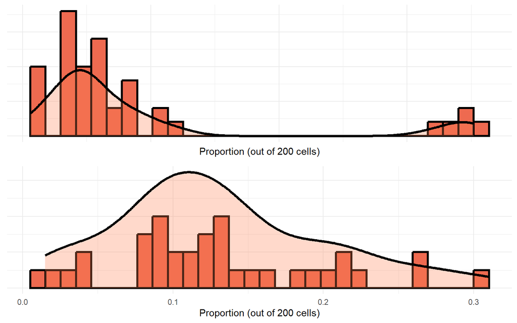

Figure 3.1: Distribution of Hyphae Formulation

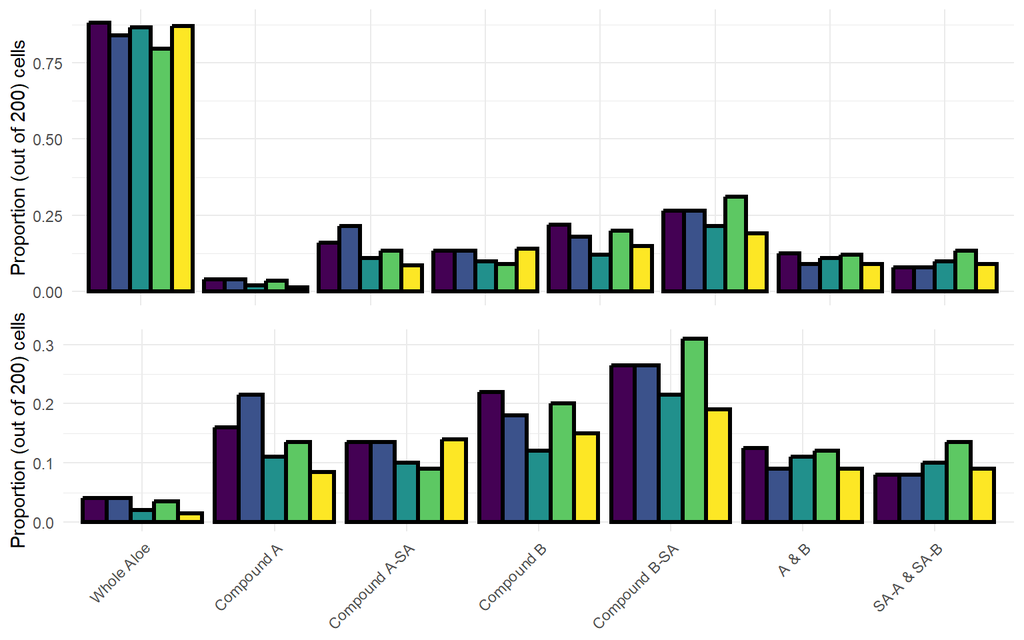

Figure 3.2: Proportion of Hyphae Found in each Replicate by Treatment Group

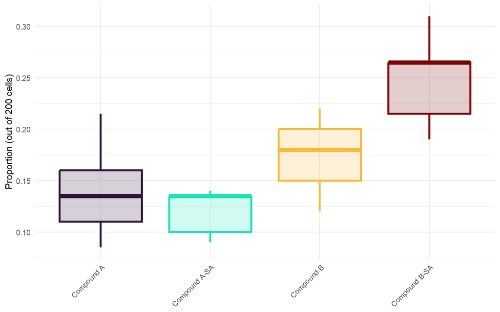

Figure 3.3: Distribution of Hyphae Found in Type A and B Compounds

## 3.2 Analyzing Hypotheses

Table 3.2 shows the results of the quasi-binomial GLM, including the estimated coefficients, the interpretable representations of those coefficients, and p-values, for each of the eight respective treatment groups. Recall that the coefficients are on the log-odds scale. Taking the whole *Aloe* treatment as an example, this means that the log-odds of hyphae forming on a cell of *Candida albicans* exposed to whole *Aloe* extract is $5.21$ lower than those under the control group. It is much more sensible to instead examine the other two columns: the relative risk and the probability columns. The relative risk column is effectively the exponentiated log-odds (the odds) scaled by 100. Thus, it is interpreted as how much percentage times more or less likely of a cell exhibiting hyphae structures as opposed to not. So we would say that cells of *Candida albicans* exposed to whole *Aloe* extract are $0.55\%$ times as likely of forming hyphae compared to cells under the control group. The probability column simply converts the odds to probability, and is simply the probability of growing Hyphae compared to the control group. From these values, we can see that cells exposed to whole *Aloe* has the lowest odds or probability of forming hyphae, and the effectiveness of the **B** compound treatments are less than that of the compound **A** counterparts.

Figure 3.4 shows the confidence intervals for the estimated mean log-odds of hyphae growth for the eight treatments. The means are effectively just the coefficients in 3.2 where the coefficients of the treatment groups are added to the estimated coefficient of the control group. Using a vertical line test can show which treatments differ from others. Clearly, all treatments are less than the control, and the whole *Aloe* group even appears to be considerably lower than the other six treatment groups. The combinatorial treatments of **A** and **B** seem they may be more effective than the **B** compounds alone, but not significantly lower than the **A** compound alone.

| Variable | Coefficient | Relative Risk | Probability | P-Value |
| --- | --- | --- | --- | --- |
| (Intercept) | 1.73 | 566.67% | 85% | < 0.0001 |
| treatmentWhole Aloe | -5.21 | 0.55% | 0.54% | < 0.0001 |
| treatmentCompound A | -3.54 | 2.9% | 2.82% | < 0.0001 |
| treatmentCompound A-SA | -3.73 | 2.41% | 2.35% | < 0.0001 |
| treatmentCompound B | -3.29 | 3.72% | 3.58% | < 0.0001 |
| treatmentCompound B-SA | -2.84 | 5.85% | 5.53% | < 0.0001 |
| treatmentA & B | -3.86 | 2.11% | 2.07% | < 0.0001 |
| treatmentSA-A & SA-B | -3.97 | 1.9% | 1.86% | < 0.0001 |

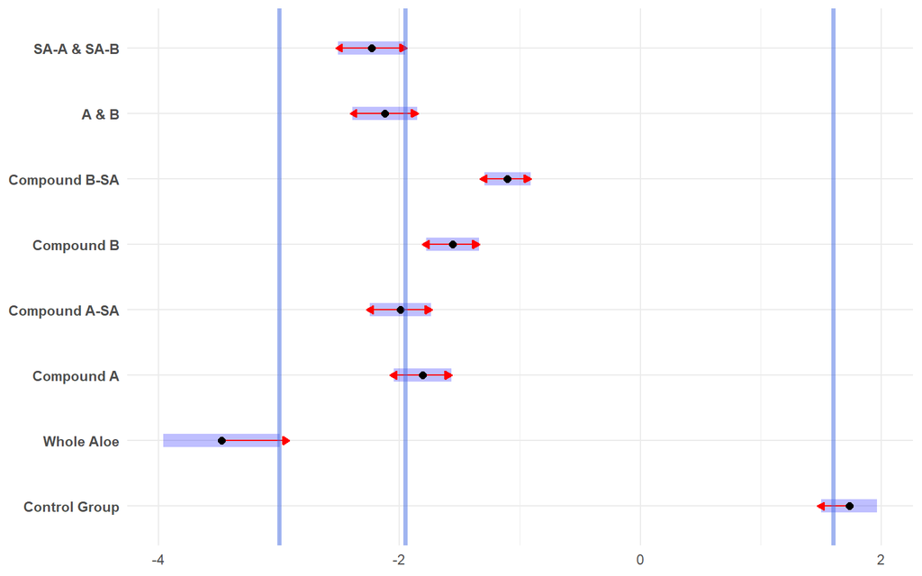

Figure 3.4: Confidence Intervals for the Eight Treatment Groups

### 3.2.1 Hypothesis 1

Table 3.3 shows the results of the contrasts comparing each treatment group to the control, under the Sidak adjustment for the p-values. All contrasts are significant, confirming (the admittedly obvious) that all treatments are more effective at stemming the growth of hyphae on *Candida albicans* cells than having no treatment. The odds-ratio column are transformed from the log-odds. Recall that the contrasts would be the differenc in the mean log-odds of hyphal formation, and thus, using the relationship that$ln(\text{odds}_1) - ln(\text{odds}_2) = ln(\frac{\text{odds}_1}{\text{odds}_2})$, then exponentiating gives the ratio of the odds. So an odds ratio greater than one means that the odds of a cell sprouting hyphae under the control group is higher than the odds under one of the treatments. Thus, for example, the odds of a cell growing hyphae with no exposure to treatment is $183$ times higher than those exposed to whole *Aloe*. The estimates of the odds ratios here suggest that whole *Aloe* is the most effective compared to the control than the other six treatments.

Table 3.3:

| contrast | odds.ratio | SE | df | null | z.ratio | p.value |
| --- | --- | --- | --- | --- | --- | --- |
| 1(Control Group) = 1(Whole Aloe) | 183.22 | 50.19 | Inf | 1 | 19.02 | < 0.0001 |
| 1(Control Group) = 1(Compound A) | 34.52 | 5.84 | Inf | 1 | 20.93 | < 0.0001 |
| 1(Control Group) = 1(Compound A-SA) | 41.56 | 7.29 | Inf | 1 | 21.24 | < 0.0001 |
| 1(Control Group) = 1(Compound B) | 26.90 | 4.36 | Inf | 1 | 20.29 | < 0.0001 |
| 1(Control Group) = 1(Compound B-SA) | 17.09 | 2.62 | Inf | 1 | 18.53 | < 0.0001 |
| 1(Control Group) = 1(A & B) | 47.29 | 8.53 | Inf | 1 | 21.37 | < 0.0001 |
| 1(Control Group) = 1(SA-A & SA-B) | 52.75 | 9.76 | Inf | 1 | 21.43 | < 0.0001 |

### 3.2.2 Hypothesis 2

Table 3.4 shows the results of the contrasts comparing the effect of the isolated compounds of natural **A** extract and the synthetic **A** compound from Sigma-Aldrich to the average of the **B** compounds. Both tests are significant, suggesting that the efficetiveness of the **A** compounds at inhibiting hyphal growth is different from the average effectiveness of the **B** compounds. Furthermore, using the relationship $ln(\text{odds}_1) - .5ln(\text{odds}_2) - .5ln(\text{odds}_3) = ln(\frac{\text{odds}_1}{\sqrt{\text{odds}_2\times\text{odds}_3}})$, then exponentiating gives us that the odds of cells exhibiting hyphal structures under one the **A** compound is $0.62$ times less the root product of the odds under either of the **B** compounds. Although this is difficult to interpret, we can view $\sqrt{\text{odds}_2\times\text{odds}_3}$ as the *geometric mean* between the odds of hyphal formation for natural and Sigma-Aldirch compounds **B**. In particular, it is a valid mean of the two odds, and thus we can interpret as odds of cells exhibiting hyphal structures under one the **A** compound is $0.62$ times less than the geometric mean odds under the **B** compounds. We can similarly interpret for the Sigma-Aldrich variant of the compound **A**. In fact, the Sigma-Aldrich variant is more effective than the mean of the other two.

Table 3.4:

| contrast | odds.ratio | SE | df | null | z.ratio | p.value |
| --- | --- | --- | --- | --- | --- | --- |
| 1(Compound A) = 0.5(Compound B) + 0.5(Compound B-SA) | 0.6211 | 0.0882 | Inf | 1 | -3.3550 | 0.0016 |
| 1(Compound A-SA) = 0.5(Compound B) + 0.5(Compound B-SA) | 0.5160 | 0.0771 | Inf | 1 | -4.4301 | < 0.0001 |

### 3.2.3 Hypothesis 3

Table 3.5:

| contrast | odds.ratio | SE | df | null | z.ratio | p.value |
| --- | --- | --- | --- | --- | --- | --- |
| 1(Whole Aloe) = 1(Compound A) | 0.19 | 0.05 | Inf | 1 | -6.06 | < 0.0001 |
| 1(Whole Aloe) = 1(Compound A-SA) | 0.23 | 0.06 | Inf | 1 | -5.31 | < 0.0001 |
| 1(Whole Aloe) = 1(Compound B) | 0.15 | 0.04 | Inf | 1 | -7.08 | < 0.0001 |
| 1(Whole Aloe) = 1(Compound B-SA) | 0.09 | 0.02 | Inf | 1 | -8.93 | < 0.0001 |
| 1(Whole Aloe) = 1(A & B) | 0.26 | 0.07 | Inf | 1 | -4.80 | < 0.0001 |
| 1(Whole Aloe) = 1(SA-A & SA-B) | 0.29 | 0.08 | Inf | 1 | -4.36 | < 0.0001 |

# 4 Conclusion

This study has demonstrated that compounds isolated from *Aloe arborescens* show significant potential in inhibiting hyphal formation in *Candida albicans*, a key morphological change linked to the pathogenicity of this fungus. By testing across seven experimental treatments, we found that all compounds derived from *Aloe arborescens* are effective in significantly reducing hyphal formation compared to an untreated control group.

Our findings support all three primary hypotheses posed in this study. We confirmed that each treatment significantly reduced hyphal formation compared to the control group, highlighting the general antifungal efficacy of these compounds. This is an important result, underscoring the potential of *Aloe arborescens* as a source for safe and effective antifungal agents. Additionally, we found that compound **A** was more effective than compound **B**, particularly the variant synthetically produced by the Sigma-Aldrich group. This suggests that compound **A** may possess a more potent antifungal mechanism than compound **B**, making it a valuable candidate for further studies. Furthermore, the added efficacy of the synthetic version provides a key insight that, if we were to use such compounds in the treatment of future patients, then purchasing the synthetic compound **A** is preferable to attempting to carefully extract it directly from the *Aloe* plant. Finally, we established that the whole *Aloe arborescens* extract is more effective than any isolated or combined treatment, indicating possible synergistic interactions among the compounds in the unrefined extract that enhance its antifungal properties.

*Aloe arborescens* represents a promising source of antifungal agents that can inhibit critical morphological transformations in *Candida albicans*. The results of this study pave the way for further research into the mechanisms of these compounds, including investigations into optimal extraction methods, potential synergies, and testing in clinical or environmental settings. Given the limited availability of safe antifungal treatments, these findings highlight the potential for *Aloe arborescens* derivatives to contribute significantly to the development of new antifungal therapies.

# References

Lenth, Russell V. 2024. “Emmeans: Estimated Marginal Means, Aka Least-Squares Means.” https://rvlenth.github.io/emmeans/.

Pennsylvania State University, Eberly College of Science. 2024. *Overdispersion in Binomial Models*. University Park, PA: Pennsylvania State University. https://online.stat.psu.edu/stat504/lesson/7/7.3.

R Core Team. 2024. *R: A Language and Environment for Statistical Computing*. Vienna, Austria: R Foundation for Statistical Computing. https://www.R-project.org/.

Smith, Allison Horst. 2019. *Custom Contrasts with Emmeans*. Blog post on aosmith.rbind.io. https://aosmith.rbind.io/2019/04/15/custom-contrasts-emmeans/.

Wickham, Hadley, Mara Averick, Jennifer Bryan, Winston Chang, Lucy D’Agostino McGowan, Romain François, Garrett Grolemund, et al. 2019. “Welcome to the Tidyverse” 4: 1686. https://doi.org/10.21105/joss.01686.

Wikipedia contributors. 2024. *Šidák correction*. Wikipedia, The Free Encyclopedia. https://en.wikipedia.org/wiki/%C5%A0id%C3%A1k_correction#See_also.

Xie, Yihui. 2024. “Knitr: A General-Purpose Package for Dynamic Report Generation in r.” https://yihui.org/knitr/.

Zhu, Hao. 2024. “kableExtra: Construct Complex Table with ’Kable’ and Pipe Syntax.” http://haozhu233.github.io/kableExtra/.